# Comparitive Study of Cluster Analysis

# 1. Segmentation Philosophy

The general goal of market segmentation is to find groups of customers that differ in important ways associated with product interest, market participation, or response to marketing efforts.

# 2. What is Segmentation/Clustering?

Segmentation is like slicing a pie, and any pie might be sliced in an infinite number of ways.

We explore two distinct yet related areas of statistics: Clustering or cluster analysis and Classification. These are the primary branches of what is sometimes called statistical learning.

## What is Supervised Learning ?

In supervised learning, a model is presented with observations whose outcome status (dependent variable) is known, with a goal to predict that outcome from the independent variables.

## What is Un-Supervised Learning ?

Un-Supervised learning we do not know the outcome groupings but attempt to discover them from structure in the data.

## Load and Explore the Data

```r
seg.raw <- read.csv("http://goo.gl/qw303p")
seg.df <- seg.raw[ , -7] # remove the known segment assignments
summary(seg.df)
```

```
##       age           gender        income            kids        ownHome
##  Min.   :19.26   Female:157   Min.   : -5183   Min.   :0.00   ownNo :159
##  1st Qu.:33.01   Male  :143   1st Qu.: 39656   1st Qu.:0.00   ownYes:141
##  Median :39.49                Median : 52014   Median :1.00
##  Mean   :41.20                Mean   : 50937   Mean   :1.27
##  3rd Qu.:47.90                3rd Qu.: 61403   3rd Qu.:2.00
##  Max.   :80.49                Max.   :114278   Max.   :7.00
##   subscribe
##  subNo :260
##  subYes: 40
##
##
##
##
```

## Steps of Clustering

Clustering analysis requires two stages: finding a proposed cluster solution and evaluating that solution for one’s business needs.

For each method we go through the following steps:

1. Transform the data if needed for a particular clustering method; for instance, some methods require all numeric data (e.g., kmeans(), mclust()) or all categorical data (e.g., poLCA()).
2. Compute a distance matrix if needed; some methods require a precomputed matrix of similarity in order to group observations (e.g., hclust()) .
3. Apply the clustering method and save its result to an object. For some methods this requires specifying the number (K) of groups desired (e.g., kmeans(), poLCA()).
4. For some methods, further parse the object to obtain a solution with K groups (e.g., hclust()).
5. Examine the solution in the model object with regard to the underlying data, and consider whether it answers a business question.

```r
seg.summ <- function(data, groups) {aggregate(data, list(groups), function(x) mean(as.numeric(x)))}
```

## Heirarchial Clustering

Hierarchical clustering is a popular method that groups observations according to their similarity.

hclust() is a distance-based algorithm that operates on a dissimilarity matrix, an N-by-N matrix that reports a metric for the distance between each pair of observations.

## How it works

The hierarchical clustering method begins with each observation in its own cluster. It then successively joins neighboring observations or clusters one at a time according to their distances from one another, and continues this until all observations are linked. This process of repeatedly joining observations and groups is known as an agglomerative method.

There are many ways to compute distance, and we start by examining the best-known method, the Euclidean distance.

The daisy() function in the cluster package [108] works with mixed data types by rescaling the values, so we use that instead of Euclidean distance:

```r
library(cluster) # daisy works with mixed data types
seg.dist <- daisy(seg.df)
seg.hc <- hclust(seg.dist, method="complete")
```

We use the complete linkage method, which evaluates the distance between every member when combining observations and groups.

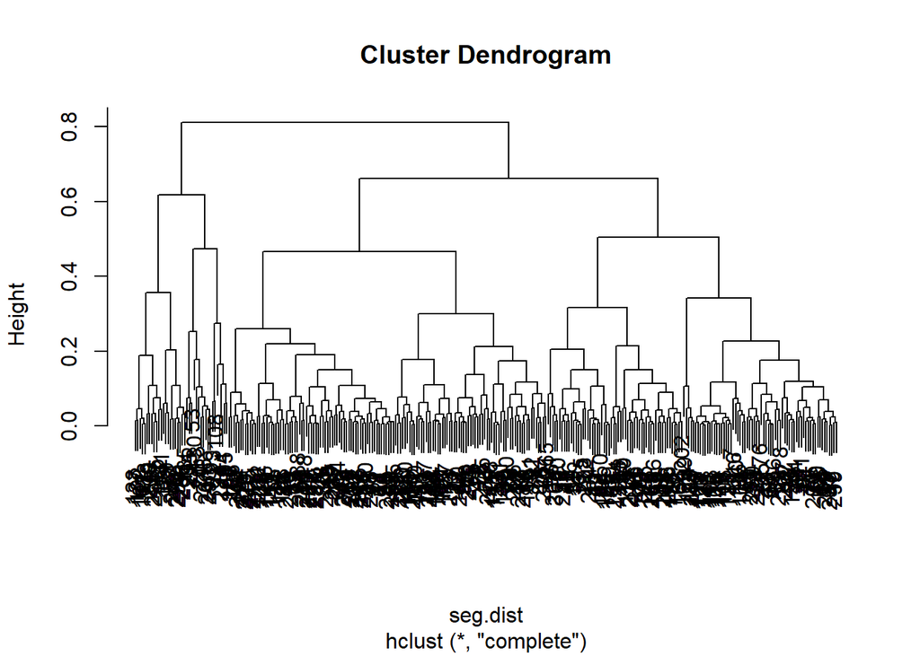

```r
plot(seg.hc)
```

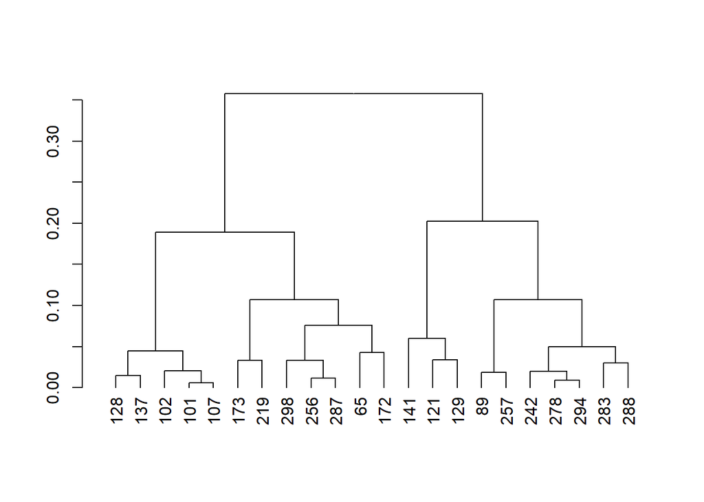

```r
plot(cut(as.dendrogram(seg.hc), h=0.5)$lower[[1]])
```

Finally, we might check one of the goodness-of-fit metrics for a hierarchical cluster solution. One method is the cophenetic correlation coefficient (CPCC), which assesses how well a dendrogram (in this case seg.hc) matches the true distance metric (seg.dist) [145]. We use cophenetic() to get the distances from the dendrogram, and compare it to the dist() metrics with cor():

```r
cor(cophenetic(seg.hc), seg.dist)
```

```
## [1] 0.7682436
```

CPCC is interpreted similarly to Pearson’s r. In this case, CPCC > 0.7 indicates a relatively strong fit, meaning that the hierarchical tree represents the distances between customers well.